# Tugas 1 — Pengantar Analisis Data Kategori

Latihan Analisis Data dengan R dan Quarto

Mahasiswa

Jason

NIM

231061012

Kode Tugas

ADK1-07018230

**Tujuan tugas.** Gunakan kembali konsep dan fungsi R yang telah dibahas pada Pertemuan 1 untuk mengenali struktur data kategori, membuat ringkasan deskriptif, memvisualisasikan data, dan menjelaskan insight secara hati-hati.

**CatatanPola kerja**

Ikuti pola kelas: **predict → run → inspect → explain**.

Pada setiap bagian diberikan **sedikit petunjuk kode**.  
Jika diminta menjelaskan atau menuliskan interpretasi, gunakan kotak **Jawaban Anda** yang telah disediakan.

# 1 1. Mengenali Data

Gunakan R untuk melihat beberapa baris awal, struktur data, dan nama variabel.

**TipPetunjuk kode**

```r
head(...)
str(...)
names(...)
```

Ganti `...` dengan objek data yang digunakan.

```r
# Tulis kode Anda di sini
head(data)
```

```
  RecordID     ProgramStudi Gender DeviceUtama ModaBelajar    Kepuasan
1   267724   Sains Aktuaria      L      Laptop       Video Sangat Puas
2   334015       Matematika      L  Smartphone     Diskusi       Cukup
3   835603       Sains Data      P      Tablet     Diskusi       Cukup
4   766204 Sistem Informasi      L      Tablet       Video Sangat Puas
5   526266 Sistem Informasi      L      Tablet     Diskusi Sangat Puas
6   722867       Sains Data      L  Smartphone       Video Sangat Puas
  IntensitasBelajar DurasiBelajarJam       PaketID
1            Tinggi             10.6 ADK1-07018230
2            Sedang              5.6 ADK1-07018230
3            Sedang              5.5 ADK1-07018230
4            Tinggi              7.9 ADK1-07018230
5            Sedang              4.5 ADK1-07018230
6            Sedang              5.3 ADK1-07018230
```

```r
str(data)
```

```
'data.frame':   107 obs. of  9 variables:
 $ RecordID         : int  267724 334015 835603 766204 526266 722867 402721 645179 582927 373786 ...
 $ ProgramStudi     : chr  "Sains Aktuaria" "Matematika" "Sains Data" "Sistem Informasi" ...
 $ Gender           : chr  "L" "L" "P" "L" ...
 $ DeviceUtama      : chr  "Laptop" "Smartphone" "Tablet" "Tablet" ...
 $ ModaBelajar      : chr  "Video" "Diskusi" "Diskusi" "Video" ...
 $ Kepuasan         : chr  "Sangat Puas" "Cukup" "Cukup" "Sangat Puas" ...
 $ IntensitasBelajar: chr  "Tinggi" "Sedang" "Sedang" "Tinggi" ...
 $ DurasiBelajarJam : num  10.6 5.6 5.5 7.9 4.5 5.3 4.1 4.1 4.4 7.1 ...
 $ PaketID          : chr  "ADK1-07018230" "ADK1-07018230" "ADK1-07018230" "ADK1-07018230" ...
```

```r
names(data)
```

```
[1] "RecordID"          "ProgramStudi"      "Gender"
[4] "DeviceUtama"       "ModaBelajar"       "Kepuasan"
[7] "IntensitasBelajar" "DurasiBelajarJam"  "PaketID"
```

Lengkapi tabel berikut.

| Variabel | Jenis Variabel | Alasan Singkat |
| --- | --- | --- |
| RecordID | Identifier (kode unik) | Hanya penanda tiap responden, tidak untuk dihitung |
| ProgramStudi | Nominal | Kategori program studi tanpa urutan |
| Gender | Nominal | Kategori L/P tanpa urutan |
| DeviceUtama | Nominal | Jenis perangkat tanpa tingkatan |
| ModaBelajar | Nominal | Cara belajar tanpa urutan |
| Kepuasan | Ordinal | Ada tingkatan: Tidak Puas < Cukup < Puas < Sangat Puas |
| IntensitasBelajar | Ordinal | Ada tingkatan: Rendah < Sedang < Tinggi |
| DurasiBelajarJam | Numerik (kontinu) | Hasil pengukuran jam, bisa dijumlah/dirata-rata |

Jawab singkat:

1. Variabel mana yang merupakan identifier?
2. Variabel mana yang bersifat ordinal?
3. Mengapa kode angka belum tentu berarti data numerik?

**Jawaban Anda**

1. `RecordID`, karena hanya kode unik untuk membedakan setiap responden (107 ID, tidak ada yang sama).
2. `Kepuasan` (Tidak Puas < Cukup < Puas < Sangat Puas) dan `IntensitasBelajar` (Rendah < Sedang < Tinggi).
3. Karena angka bisa hanya berfungsi sebagai label (misalnya `RecordID`), sehingga menjumlah atau merata-ratakannya tidak bermakna. Jenis variabel ditentukan oleh arti datanya, bukan oleh tampilannya.

# 2 2. Menyiapkan Data Kategori

Variabel latihan Anda:

```r
cat("Nominal :", identitas$nominal_utama[1], "\n")
```

```
Nominal : DeviceUtama
```

```r
cat("Ordinal :", identitas$ordinal_utama[1], "\n")
```

```
Ordinal : Kepuasan
```

```r
cat("Urutan  :", identitas$urutan_ordinal[1], "\n")
```

```
Urutan  : Tidak Puas|Cukup|Puas|Sangat Puas
```

Lakukan hal berikut:

1. ubah variabel nominal menjadi factor;
2. ubah variabel ordinal menjadi ordered factor;
3. periksa level kategorinya.

**TipPetunjuk kode**

Untuk nominal:

```r
factor(...)
levels(...)
```

Untuk ordinal:

```r
factor(..., levels = ..., ordered = TRUE)
```

```r
nominal_var <- identitas$nominal_utama[1]
ordinal_var <- identitas$ordinal_utama[1]
urutan <- strsplit(identitas$urutan_ordinal[1], "\\|")[[1]]

# Tulis kode Anda di bawah ini
data[[nominal_var]] <- factor(data[[nominal_var]])
data[[ordinal_var]] <- factor(data[[ordinal_var]], levels = urutan, ordered = TRUE)

levels(data[[nominal_var]])
```

```
[1] "Laptop"     "Smartphone" "Tablet"
```

```r
levels(data[[ordinal_var]])
```

```
[1] "Tidak Puas"  "Cukup"       "Puas"        "Sangat Puas"
```

Tuliskan satu kalimat: **mengapa urutan level ordinal perlu ditetapkan dengan benar?**

**Jawaban Anda**

Urutan level harus ditetapkan agar R tidak mengurutkannya secara alfabet (Cukup, Puas, Sangat Puas, Tidak Puas), sehingga tabel dan grafik menampilkan tingkatan kepuasan yang benar dari Tidak Puas sampai Sangat Puas.

# 3 3. Quality Control Awal

Lakukan pemeriksaan sederhana terhadap:

- struktur data;
- level/kategori;
- missing value;
- konsistensi penulisan kategori.

**TipPetunjuk kode**

Beberapa pola fungsi yang dapat digunakan:

```r
str(...)
levels(...)
unique(...)
is.na(...)
colSums(...)
```

Pilih fungsi yang sesuai dengan tujuan pemeriksaan Anda.

```r
# Tulis kode Anda di sini
str(data)                         # struktur data
```

```
'data.frame':   107 obs. of  9 variables:
 $ RecordID         : int  267724 334015 835603 766204 526266 722867 402721 645179 582927 373786 ...
 $ ProgramStudi     : chr  "Sains Aktuaria" "Matematika" "Sains Data" "Sistem Informasi" ...
 $ Gender           : chr  "L" "L" "P" "L" ...
 $ DeviceUtama      : Factor w/ 3 levels "Laptop","Smartphone",..: 1 2 3 3 3 2 1 1 3 1 ...
 $ ModaBelajar      : chr  "Video" "Diskusi" "Diskusi" "Video" ...
 $ Kepuasan         : Ord.factor w/ 4 levels "Tidak Puas"<"Cukup"<..: 4 2 2 4 4 4 3 3 4 3 ...
 $ IntensitasBelajar: chr  "Tinggi" "Sedang" "Sedang" "Tinggi" ...
 $ DurasiBelajarJam : num  10.6 5.6 5.5 7.9 4.5 5.3 4.1 4.1 4.4 7.1 ...
 $ PaketID          : chr  "ADK1-07018230" "ADK1-07018230" "ADK1-07018230" "ADK1-07018230" ...
```

```r
levels(data[[nominal_var]])       # level nominal
```

```
[1] "Laptop"     "Smartphone" "Tablet"
```

```r
levels(data[[ordinal_var]])       # level ordinal (urut)
```

```
[1] "Tidak Puas"  "Cukup"       "Puas"        "Sangat Puas"
```

```r
unique(data$ModaBelajar)          # cek konsistensi penulisan kategori
```

```
[1] "Video"   "Diskusi" "Praktik" "Buku"    NA
```

```r
unique(data$IntensitasBelajar)
```

```
[1] "Tinggi" "Sedang" "Rendah" NA
```

```r
colSums(is.na(data))              # missing value per kolom
```

```
         RecordID      ProgramStudi            Gender       DeviceUtama
                0                 0                 0                 1
      ModaBelajar          Kepuasan IntensitasBelajar  DurasiBelajarJam
                1                 2                 1                 0
          PaketID
                0
```

```r
sum(duplicated(data$RecordID))    # cek ID ganda
```

```
[1] 0
```

Tuliskan **dua temuan singkat** dari pemeriksaan tersebut.

**Jawaban Anda**

1. Terdapat 5 baris dengan nilai kosong (*missing*): `DeviceUtama` 1, `ModaBelajar` 1, `Kepuasan` 2, dan `IntensitasBelajar` 1. Jadi analisis `DeviceUtama` memakai 106 data, dan `Kepuasan` memakai 105 data.
2. Penulisan kategori sudah konsisten (tidak ada salah ketik atau perbedaan huruf besar/kecil), dan `RecordID` unik tanpa duplikat sehingga datanya cukup bersih. Jumlah level sesuai: 3 level `DeviceUtama` dan 4 level `Kepuasan`.

# 4 4. Frekuensi dan Proporsi

Sebelum menjalankan kode, prediksi:

> Menurut Anda, kategori mana yang paling banyak muncul pada variabel nominal Anda?

**Prediksi Anda**

Saya memprediksi kategori **Laptop** paling banyak muncul, karena laptop umum dipakai mahasiswa untuk belajar.

Setelah itu, buat:

- tabel frekuensi untuk variabel nominal;
- proporsi untuk variabel ordinal.

**TipPetunjuk kode**

```r
table(...)
prop.table(...)
```

Anda dapat menyimpan hasil `table()` ke sebuah objek terlebih dahulu sebelum menghitung proporsi.

```r
# Tulis kode Anda di sini
# Frekuensi variabel nominal
tab_nominal <- table(data[[nominal_var]])
tab_nominal
```

```
    Laptop Smartphone     Tablet
        59         21         26
```

```r
round(prop.table(tab_nominal), 3)
```

```
    Laptop Smartphone     Tablet
     0.557      0.198      0.245
```

```r
# Proporsi variabel ordinal
tab_ordinal <- table(data[[ordinal_var]])
tab_ordinal
```

```
 Tidak Puas       Cukup        Puas Sangat Puas
          7          25          35          38
```

```r
round(prop.table(tab_ordinal), 3)
```

```
 Tidak Puas       Cukup        Puas Sangat Puas
      0.067       0.238       0.333       0.362
```

Tuliskan **dua kalimat insight** berdasarkan output.

**Interpretasi Anda**

1. `DeviceUtama` didominasi **Laptop** (59 dari 106 mahasiswa, sekitar 55,7%), diikuti Tablet (26; 24,5%) dan Smartphone (21; 19,8%). Prediksi saya sesuai dengan hasilnya.
2. Pada `Kepuasan`, mayoritas berada di kategori puas: Sangat Puas 36,2% dan Puas 33,3% (total sekitar 69,5%), sedangkan Tidak Puas hanya 6,7%.

# 5 5. Tabel Silang

Pasangan variabel Anda:

```r
x <- identitas$tab_baris[1]
y <- identitas$tab_kolom[1]

cat("Baris :", x, "\n")
```

```
Baris : ModaBelajar
```

```r
cat("Kolom :", y, "\n")
```

```
Kolom : IntensitasBelajar
```

Buat tabel silang untuk kedua variabel tersebut.

Jika diperlukan, tampilkan proporsi per baris untuk membantu membaca pola.

**TipPetunjuk kode**

```r
table(..., ...)
prop.table(..., margin = 1)
```

Lengkapi sendiri objek yang diperlukan.

```r
# Tulis kode Anda di sini
data[[y]] <- factor(data[[y]], levels = c("Rendah", "Sedang", "Tinggi"), ordered = TRUE)

tab_silang <- table(data[[x]], data[[y]])
tab_silang
```

```
          Rendah Sedang Tinggi
  Buku         9      5      5
  Diskusi     12     11     13
  Praktik      7      6      8
  Video       10      9     10
```

```r
round(prop.table(tab_silang, margin = 1), 3)   # proporsi per baris
```

```
          Rendah Sedang Tinggi
  Buku     0.474  0.263  0.263
  Diskusi  0.333  0.306  0.361
  Praktik  0.333  0.286  0.381
  Video    0.345  0.310  0.345
```

Tuliskan **satu kalimat** yang menjelaskan pola yang tampak.

**Interpretasi Anda**

Pada setiap moda belajar, intensitas belajar tersebar cukup merata, tetapi moda *Buku* menonjol dengan proporsi intensitas Rendah paling besar (47,4%), sedangkan Praktik memiliki proporsi Tinggi terbesar (38,1%); ini hanya gambaran deskriptif, bukan bukti hubungan.

**Penting**

Gunakan bahasa deskriptif. Jangan langsung menyimpulkan adanya hubungan signifikan atau sebab-akibat.

# 6 6. Visualisasi Kategorik

Variabel yang divisualisasikan:

```r
v <- identitas$visualisasi[1]
cat("Variabel grafik :", v, "\n")
```

```
Variabel grafik : Kepuasan
```

Buat **satu grafik batang** seperti yang telah dipelajari pada Pertemuan 1.

**TipPetunjuk kode**

```r
library(ggplot2)

ggplot(..., aes(x = ...)) +
  geom_bar() +
  labs(...)
```

Sesuaikan objek data, variabel, judul, dan label sumbu.

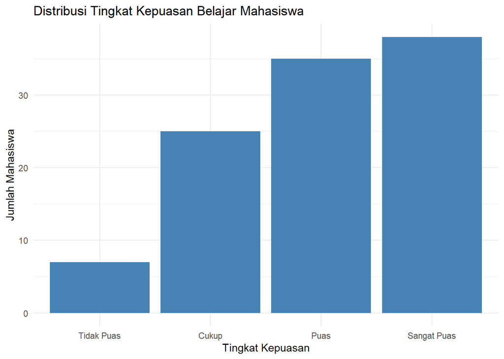

```r
# Tulis kode Anda di sini
library(ggplot2)

ggplot(data[!is.na(data[[v]]), ], aes(x = .data[[v]])) +
  geom_bar(fill = "steelblue") +
  labs(
    title = "Distribusi Tingkat Kepuasan Belajar Mahasiswa",
    x = "Tingkat Kepuasan",
    y = "Jumlah Mahasiswa"
  ) +
  theme_minimal()
```

Tuliskan **satu kalimat** interpretasi grafik.

**Interpretasi Anda**

Batang tertinggi ada pada kategori Sangat Puas (38 mahasiswa), disusul Puas (35) dan Cukup (25), sedangkan Tidak Puas paling sedikit (7), sehingga kepuasan cenderung berada di sisi positif.

# 7 7. Kesimpulan

Tuliskan **3 poin kesimpulan singkat** berdasarkan hasil analisis.

Setiap kesimpulan harus:

- didukung oleh output yang telah Anda hasilkan;
- menggunakan angka yang relevan;
- ditulis dengan bahasa Anda sendiri;
- tidak menggunakan klaim sebab-akibat.

**Kesimpulan Anda**

1. Perangkat utama mahasiswa didominasi Laptop (59 dari 106 responden, 55,7%), jauh di atas Tablet (24,5%) dan Smartphone (19,8%).
2. Tingkat kepuasan cenderung tinggi: 73 dari 105 responden (69,5%) menjawab Puas atau Sangat Puas, sedangkan hanya 7 (6,7%) yang Tidak Puas.
3. Pada tabel silang, intensitas belajar relatif merata di tiap moda belajar, kecuali moda Buku yang 47,4% berintensitas Rendah (dibanding sekitar 33-35% pada moda lain); pola ini hanya deskriptif dan tidak menunjukkan sebab-akibat.

**Analisis Data Kategori — Tugas 1**  
Predict → Run → Inspect → Explain